# Text visualization

MACS 40700 University of Chicago

May 22, 2017

# Basic workflow for text analysis

- Obtain your text sources
- Extract documents and move into a corpus
- Transformation
- Extract features
- Perform analysis

# Obtain your text sources

- Web sites
  - Twitter
- Databases
- PDF documents
- Digital scans of printed materials

# Extract documents and move into a corpus

- Corpus
- Character string

# Transformation

- Tagging segments of speech for part-of-speech (nouns, verbs, adjectives, etc.) or entity recognition (person, place, company, etc.)
- Standard text processing
  - Converting to lower case
  - Removing punctuation
  - Removing numbers
  - Removing stopwords
  - Removing domain-specific stopwords
  - Stemming

# Extract features

- Quantify your measures
- Bag-of-words model
- Term-document matrix
  - Each row is a document
  - Each column is a term
  - Each cell represents the frequency of the term appearing in the document
- Missing context

# Perform analysis

- Word frequency
- Collocation
- Dictionary tagging
- Document classification
- Corpora comparison
- Topic modeling

# Wordclouds

# N-gram viewers

- N-gram
- [Google Books Ngram Viewer](https://books.google.com/ngrams)
  - [Calendar of Meaningful Dates](https://www.xkcd.com/1140/)
- [How The Internet* Talks](https://projects.fivethirtyeight.com/reddit-ngram/?keyword=triggered.safe_space.sjw.snowflake&start=20071015&end=20161231&smoothing=10)

# Geospatial visualization

- [Which Curse Words Are Popular In Your State? Find Out From These Maps.](http://www.huffingtonpost.com/entry/which-curse-words-are-popular-in-your-state_us_55a80662e4b04740a3df54b8)
- [Hate Map](http://users.humboldt.edu/mstephens/hate/hate_map.html)
- [Soda vs. Pop with Twitter](http://blog.echen.me/2012/07/06/soda-vs-pop-with-twitter/)

# Network analysis with text

- Use text features to identify edges between nodes in a network
- [How every #GameOfThrones episode has been discussed on Twitter](https://interactive.twitter.com/game-of-thrones/#?episode=1)

# Sentiment analysis

> I am happy

# Dictionaries

```
## # A tibble: 6,788 x 2
##           word sentiment
##          <chr>     <chr>
##  1     2-faced  negative
##  2     2-faces  negative
##  3          a+  positive
##  4    abnormal  negative
##  5     abolish  negative
##  6  abominable  negative
##  7  abominably  negative
##  8   abominate  negative
##  9 abomination  negative
## 10       abort  negative
## # ... with 6,778 more rows
```

# Dictionaries

```
## # A tibble: 2,476 x 2
##          word score
##         <chr> <int>
##  1    abandon    -2
##  2  abandoned    -2
##  3   abandons    -2
##  4   abducted    -2
##  5  abduction    -2
##  6 abductions    -2
##  7      abhor    -3
##  8   abhorred    -3
##  9  abhorrent    -3
## 10     abhors    -3
## # ... with 2,466 more rows
```

# Dictionaries

```
## # A tibble: 13,901 x 2
##           word sentiment
##          <chr>     <chr>
##  1      abacus     trust
##  2     abandon      fear
##  3     abandon  negative
##  4     abandon   sadness
##  5   abandoned     anger
##  6   abandoned      fear
##  7   abandoned  negative
##  8   abandoned   sadness
##  9 abandonment     anger
## 10 abandonment      fear
## # ... with 13,891 more rows
```

# Dictionaries

```
## # A tibble: 10 x 2
##       sentiment     n
##           <chr> <int>
##  1        anger  1247
##  2 anticipation   839
##  3      disgust  1058
##  4         fear  1476
##  5          joy   689
##  6     negative  3324
##  7     positive  2312
##  8      sadness  1191
##  9     surprise   534
## 10        trust  1231
```

# Measuring overall sentiment

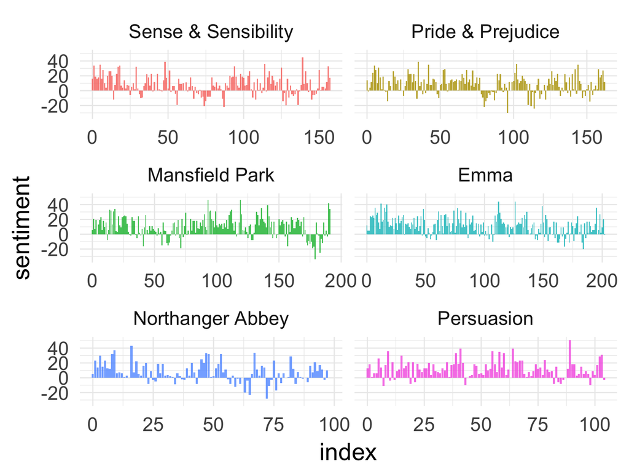

# @realDonaldTrump

> Every non-hyperbolic tweet is from iPhone (his staff).  
> Every hyperbolic tweet is from Android (from him). [pic.twitter.com/GWr6D8h5ed](https://t.co/GWr6D8h5ed)

> — Todd Vaziri (@tvaziri) [August 6, 2016](https://twitter.com/tvaziri/status/762005541388378112)

# Obtaining documents

```
## [1] "Using browser based authentication"
```

```
## Classes 'tbl_df', 'tbl' and 'data.frame':    1512 obs. of  16 variables:
##  $ text         : chr  "My economic policy speech will be carried live at 12:15 P.M. Enjoy!" "Join me in Fayetteville, North Carolina tomorrow evening at 6pm. Tickets now available at: https://t.co/Z80d4MYIg8" "#ICYMI: \"Will Media Apologize to Trump?\" https://t.co/ia7rKBmioA" "Michael Morell, t…
##  $ favorited    : logi  FALSE FALSE FALSE FALSE FALSE FALSE ...
##  $ favoriteCount: num  9214 6981 15724 19837 34051 ...
##  $ replyToSN    : chr  NA NA NA NA ...
##  $ created      : POSIXct, format: "2016-08-08 15:20:44" "2016-08-08 13:28:20" ...
##  $ truncated    : logi  FALSE FALSE FALSE FALSE FALSE FALSE ...
##  $ replyToSID   : logi  NA NA NA NA NA NA ...
##  $ id           : chr  "762669882571980801" "762641595439190016" "762439658911338496" "762425371874557952" ...
##  $ replyToUID   : chr  NA NA NA NA ...
##  $ statusSource : chr  "<a href=\"http://twitter.com/download/android\" rel=\"nofollow\">Twitter for Android</a>" "<a href=\"http://twitter.com/download/iphone\" rel=\"nofollow\">Twitter for iPhone</a>" "<a href=\"http://twitter.com/download/iphone\" rel=\"nofollow\">Twitter for iPhone</a>" "<a h…
##  $ screenName   : chr  "realDonaldTrump" "realDonaldTrump" "realDonaldTrump" "realDonaldTrump" ...
##  $ retweetCount : num  3107 2390 6691 6402 11717 ...
##  $ isRetweet    : logi  FALSE FALSE FALSE FALSE FALSE FALSE ...
##  $ retweeted    : logi  FALSE FALSE FALSE FALSE FALSE FALSE ...
##  $ longitude    : chr  NA NA NA NA ...
##  $ latitude     : chr  NA NA NA NA ...
```

# Clean up the data

| id | source | text | created |
| --- | --- | --- | --- |
| 762669882571980801 | Android | My economic policy speech will be carried live at 12:15 P.M. Enjoy! | 2016-08-08 15:20:44 |
| 762641595439190016 | iPhone | Join me in Fayetteville, North Carolina tomorrow evening at 6pm. Tickets now available at: https://t.co/Z80d4MYIg8 | 2016-08-08 13:28:20 |
| 762439658911338496 | iPhone | #ICYMI: “Will Media Apologize to Trump?” https://t.co/ia7rKBmioA | 2016-08-08 00:05:54 |
| 762425371874557952 | Android | Michael Morell, the lightweight former Acting Director of C.I.A., and a man who has made serious bad calls, is a total Clinton flunky! | 2016-08-07 23:09:08 |
| 762400869858115588 | Android | The media is going crazy. They totally distort so many things on purpose. Crimea, nuclear, “the baby” and so much more. Very dishonest! | 2016-08-07 21:31:46 |
| 762284533341417472 | Android | I see where Mayor Stephanie Rawlings-Blake of Baltimore is pushing Crooked hard. Look at the job she has done in Baltimore. She is a joke! | 2016-08-07 13:49:29 |

# Trump tweets

| id | source | text | created |
| --- | --- | --- | --- |
| 762669882571980801 | Android | My economic policy speech will be carried live at 12:15 P.M. Enjoy! | 2016-08-08 15:20:44 |
| 762641595439190016 | iPhone | Join me in Fayetteville, North Carolina tomorrow evening at 6pm. Tickets now available at: https://t.co/Z80d4MYIg8 | 2016-08-08 13:28:20 |
| 762439658911338496 | iPhone | #ICYMI: “Will Media Apologize to Trump?” https://t.co/ia7rKBmioA | 2016-08-08 00:05:54 |
| 762425371874557952 | Android | Michael Morell, the lightweight former Acting Director of C.I.A., and a man who has made serious bad calls, is a total Clinton flunky! | 2016-08-07 23:09:08 |
| 762400869858115588 | Android | The media is going crazy. They totally distort so many things on purpose. Crimea, nuclear, “the baby” and so much more. Very dishonest! | 2016-08-07 21:31:46 |
| 762284533341417472 | Android | I see where Mayor Stephanie Rawlings-Blake of Baltimore is pushing Crooked hard. Look at the job she has done in Baltimore. She is a joke! | 2016-08-07 13:49:29 |

# Remove manual retweets

| id | source | text | created |
| --- | --- | --- | --- |
| 762669882571980801 | Android | My economic policy speech will be carried live at 12:15 P.M. Enjoy! | 2016-08-08 15:20:44 |
| 762641595439190016 | iPhone | Join me in Fayetteville, North Carolina tomorrow evening at 6pm. Tickets now available at: https://t.co/Z80d4MYIg8 | 2016-08-08 13:28:20 |
| 762439658911338496 | iPhone | #ICYMI: “Will Media Apologize to Trump?” https://t.co/ia7rKBmioA | 2016-08-08 00:05:54 |
| 762425371874557952 | Android | Michael Morell, the lightweight former Acting Director of C.I.A., and a man who has made serious bad calls, is a total Clinton flunky! | 2016-08-07 23:09:08 |
| 762400869858115588 | Android | The media is going crazy. They totally distort so many things on purpose. Crimea, nuclear, “the baby” and so much more. Very dishonest! | 2016-08-07 21:31:46 |
| 762284533341417472 | Android | I see where Mayor Stephanie Rawlings-Blake of Baltimore is pushing Crooked hard. Look at the job she has done in Baltimore. She is a joke! | 2016-08-07 13:49:29 |

# Tokenize

| id | source | created | word |
| --- | --- | --- | --- |
| 676494179216805888 | iPhone | 2015-12-14 20:09:15 | record |
| 676494179216805888 | iPhone | 2015-12-14 20:09:15 | of |
| 676494179216805888 | iPhone | 2015-12-14 20:09:15 | health |
| 676494179216805888 | iPhone | 2015-12-14 20:09:15 | #makeamericagreatagain |
| 676494179216805888 | iPhone | 2015-12-14 20:09:15 | #trump2016 |
| 676509769562251264 | iPhone | 2015-12-14 21:11:12 | another |

# Remove stop words

| id | source | created | word |
| --- | --- | --- | --- |
| 676494179216805888 | iPhone | 2015-12-14 20:09:15 | record |
| 676494179216805888 | iPhone | 2015-12-14 20:09:15 | health |
| 676494179216805888 | iPhone | 2015-12-14 20:09:15 | #makeamericagreatagain |
| 676494179216805888 | iPhone | 2015-12-14 20:09:15 | #trump2016 |
| 676509769562251264 | iPhone | 2015-12-14 21:11:12 | accolade |
| 676509769562251264 | iPhone | 2015-12-14 21:11:12 | @trumpgolf |

# Frequency of tokens

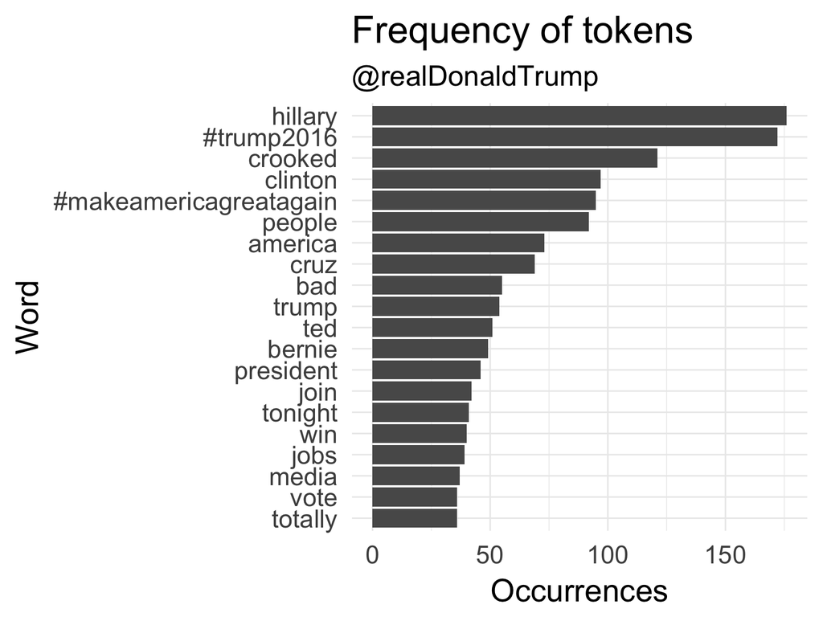

# Assessing word importance

- Term frequency (tf)
- Inverse document frequency (idf)
- Term frequency-inverse document frequency (tf-idf)

  $$idf(\text{term}) = \ln{\left(\frac{n_{\text{documents}}}{n_{\text{documents containing term}}}\right)}$$

# Calculate tf-idf

```
## # A tibble: 3,235 x 3
##     source                   word     n
##      <chr>                  <chr> <int>
##  1  iPhone             #trump2016   171
##  2 Android                hillary   124
##  3  iPhone #makeamericagreatagain    95
##  4 Android                crooked    93
##  5 Android                clinton    66
##  6 Android                 people    64
##  7  iPhone                hillary    52
##  8 Android                   cruz    50
##  9 Android                    bad    43
## 10  iPhone                america    43
## # ... with 3,225 more rows
```

# Calculate tf-idf

```
## # A tibble: 2 x 2
##    source total
##     <chr> <int>
## 1 Android  4901
## 2  iPhone  3852
```

# Calculate tf-idf

```
## # A tibble: 3,235 x 4
##     source                   word     n total
##      <chr>                  <chr> <int> <int>
##  1  iPhone             #trump2016   171  3852
##  2 Android                hillary   124  4901
##  3  iPhone #makeamericagreatagain    95  3852
##  4 Android                crooked    93  4901
##  5 Android                clinton    66  4901
##  6 Android                 people    64  4901
##  7  iPhone                hillary    52  3852
##  8 Android                   cruz    50  4901
##  9 Android                    bad    43  4901
## 10  iPhone                america    43  3852
## # ... with 3,225 more rows
```

# Calculate tf-idf

```
## # A tibble: 3,235 x 7
##     source                   word     n total      tf   idf tf_idf
##      <chr>                  <chr> <int> <int>   <dbl> <dbl>  <dbl>
##  1  iPhone             #trump2016   171  3852 0.04439 0.000 0.0000
##  2 Android                hillary   124  4901 0.02530 0.000 0.0000
##  3  iPhone #makeamericagreatagain    95  3852 0.02466 0.693 0.0171
##  4 Android                crooked    93  4901 0.01898 0.000 0.0000
##  5 Android                clinton    66  4901 0.01347 0.000 0.0000
##  6 Android                 people    64  4901 0.01306 0.000 0.0000
##  7  iPhone                hillary    52  3852 0.01350 0.000 0.0000
##  8 Android                   cruz    50  4901 0.01020 0.000 0.0000
##  9 Android                    bad    43  4901 0.00877 0.000 0.0000
## 10  iPhone                america    43  3852 0.01116 0.000 0.0000
## # ... with 3,225 more rows
```

# Which terms have a high tf-idf?

```
## # A tibble: 3,235 x 6
##     source                   word     n      tf   idf  tf_idf
##      <chr>                  <chr> <int>   <dbl> <dbl>   <dbl>
##  1  iPhone #makeamericagreatagain    95 0.02466 0.693 0.01709
##  2  iPhone                   join    42 0.01090 0.693 0.00756
##  3  iPhone          #americafirst    27 0.00701 0.693 0.00486
##  4  iPhone             #votetrump    23 0.00597 0.693 0.00414
##  5  iPhone             #imwithyou    20 0.00519 0.693 0.00360
##  6  iPhone        #crookedhillary    17 0.00441 0.693 0.00306
##  7  iPhone          #trumppence16    14 0.00363 0.693 0.00252
##  8  iPhone                    7pm    11 0.00286 0.693 0.00198
##  9  iPhone                  video    11 0.00286 0.693 0.00198
## 10 Android                  badly    13 0.00265 0.693 0.00184
## # ... with 3,225 more rows
```

# Which terms have a high tf-idf?

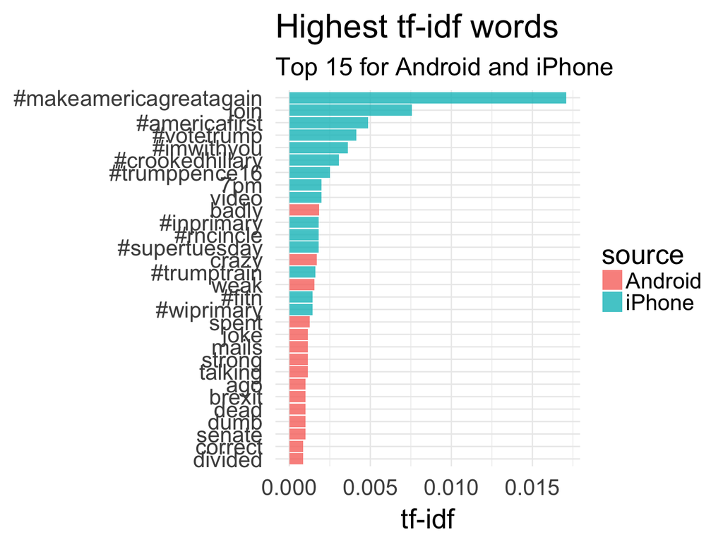

# Sentiment analysis

```
## # A tibble: 13,901 x 2
##           word sentiment
##          <chr>     <chr>
##  1      abacus     trust
##  2     abandon      fear
##  3     abandon  negative
##  4     abandon   sadness
##  5   abandoned     anger
##  6   abandoned      fear
##  7   abandoned  negative
##  8   abandoned   sadness
##  9 abandonment     anger
## 10 abandonment      fear
## # ... with 13,891 more rows
```

# Sentiment analysis

```
## # A tibble: 1,172 x 3
##                    id  source total_words
##                 <chr>   <chr>       <int>
##  1 676494179216805888  iPhone        3852
##  2 676509769562251264  iPhone        3852
##  3 680496083072593920 Android        4901
##  4 680503951440121856 Android        4901
##  5 680505672476262400 Android        4901
##  6 680734915718176768 Android        4901
##  7 682764544402440192  iPhone        3852
##  8 682792967736848385  iPhone        3852
##  9 682805320217980929  iPhone        3852
## 10 685490467329425408 Android        4901
## # ... with 1,162 more rows
```

# Sentiment analysis

```
## # A tibble: 6 x 4
##    source    sentiment total_words words
##     <chr>        <chr>       <int> <dbl>
## 1 Android        anger        4901   321
## 2 Android anticipation        4901   256
## 3 Android      disgust        4901   207
## 4 Android         fear        4901   268
## 5 Android          joy        4901   199
## 6 Android     negative        4901   560
```

# Is this significant?

```
## # A tibble: 10 x 9
##       sentiment estimate statistic  p.value parameter conf.low conf.high
##           <chr>    <dbl>     <dbl>    <dbl>     <dbl>    <dbl>     <dbl>
##  1        anger     1.49       321 2.19e-05       274    1.235      1.81
##  2 anticipation     1.17       256 1.19e-01       240    0.960      1.43
##  3      disgust     1.68       207 1.78e-05       170    1.312      2.16
##  4         fear     1.56       268 1.89e-05       226    1.264      1.93
##  5          joy     1.00       199 1.00e+00       199    0.809      1.24
##  6     negative     1.69       560 7.09e-13       459    1.459      1.97
##  7     positive     1.06       555 3.82e-01       541    0.930      1.21
##  8      sadness     1.62       303 1.15e-06       252    1.326      1.99
##  9     surprise     1.17       159 2.17e-01       149    0.908      1.51
## 10        trust     1.13       369 1.47e-01       351    0.960      1.33
## # ... with 2 more variables: method <fctr>, alternative <fctr>
```

# Is this significant?

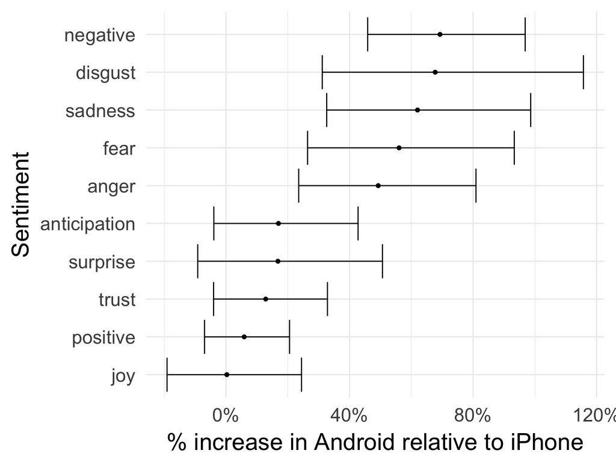

# Most important words

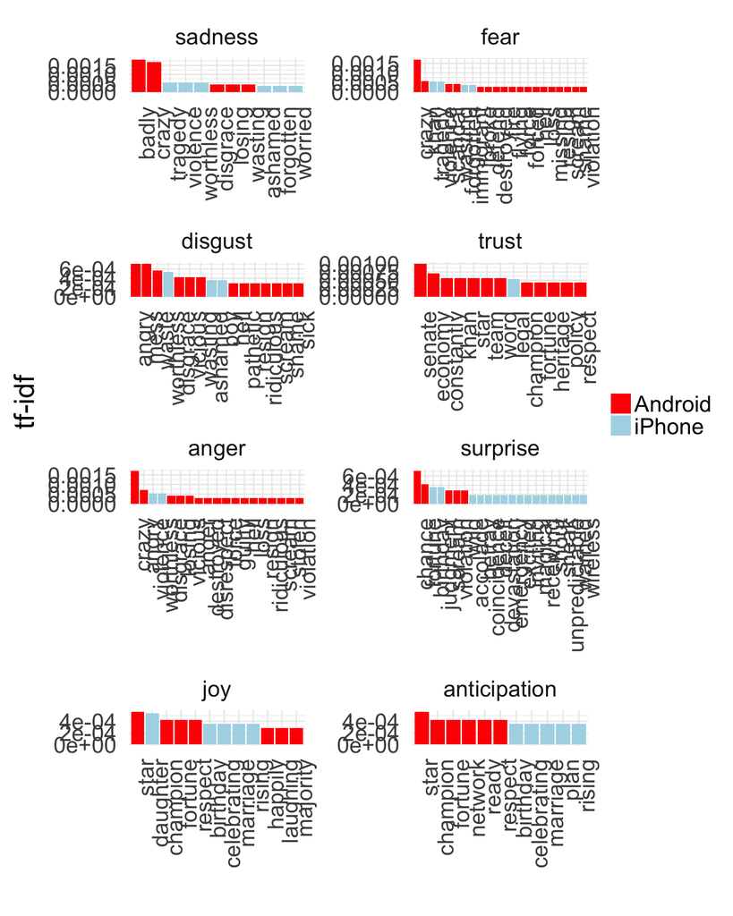

# Bag-of-words

```
 a abandoned abc ability able about above abroad absorbed absorbing abstract
43         0   0       0    0    10     0      0        0         0        1
```

1. Sparsity
2. Stop words
3. Correlation between words

# Latent semantic analysis

- Identify words closely related to one another
- Makes searching by keyword easier
- Uses PCA or similar techinques

# `NYTimes`

```
##  [1] "penchant"  "brought"   "structure" "willing"   "yielding"
##  [6] "bare"      "school"    "halls"     "challenge" "step"
## [11] "largest"   "lovers"    "intense"   "borders"   "mall"
## [16] "classic"   "conducted" "mirrors"   "hole"      "location"
## [21] "desperate" "published" "head"      "paints"    "another"
## [26] "starts"    "familiar"  "window"    "thats"     "broker"
```

# `NYTimes`

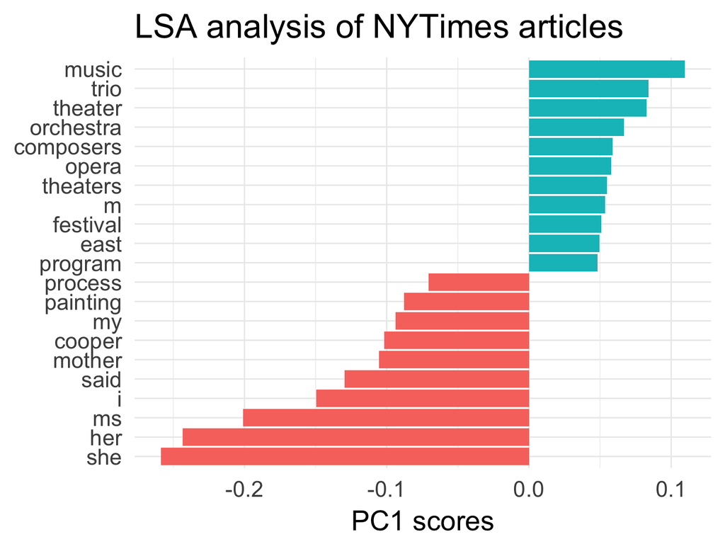

# `NYTimes`

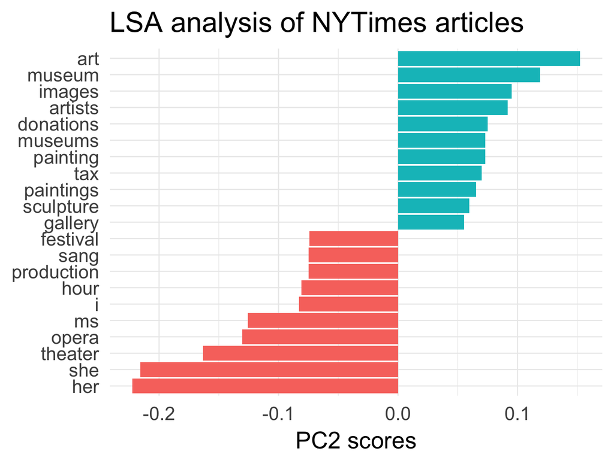

# `NYTimes`

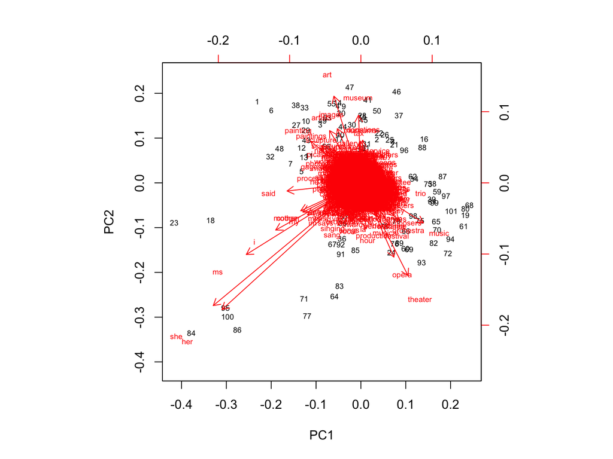

# `NYTimes`

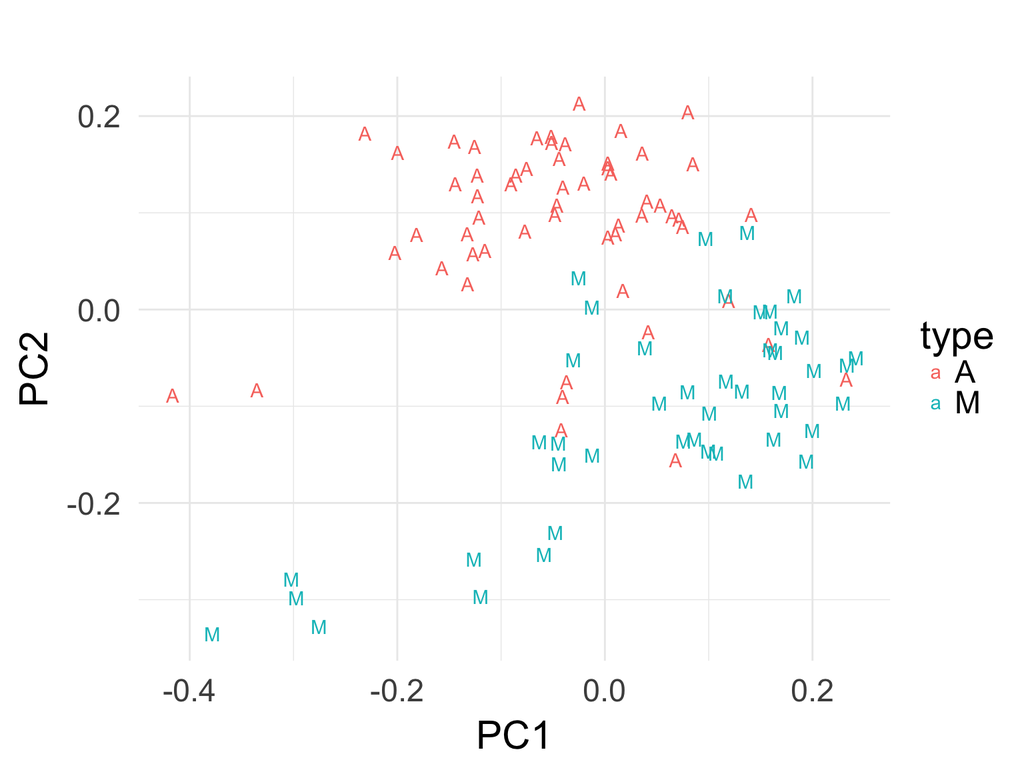

```
## List of 1
##  $ legend.position: chr "none"
##  - attr(*, "class")= chr [1:2] "theme" "gg"
##  - attr(*, "complete")= logi FALSE
##  - attr(*, "validate")= logi TRUE
```